# Course Project Part 2 - Tooth Growth

Scott Jacobs

Now in the second portion of the class, we’re going to analyze the ToothGrowth data in the R datasets package. Load the ToothGrowth data and perform some basic exploratory data analyses Provide a basic summary of the data. Use confidence intervals and/or hypothesis tests to compare tooth growth by supp and dose. (Only use the techniques from class, even if there’s other approaches worth considering) State your conclusions and the assumptions needed for your conclusions.

#### Question 1. Response follows;

```r
#Load the data ToothGrowth and provide a basic summary
data(ToothGrowth)
```

# The Effect of Vitamin C on Tooth Growth in Guinea Pigs

## Description

The response is the length of odontoblasts (teeth) in each of 10 guinea pigs at each of three dose levels of Vitamin C (0.5, 1, and 2 mg) with each of two delivery methods (orange juice or ascorbic acid).

```
##       len        supp         dose
##  Min.   : 4.20   OJ:30   Min.   :0.500
##  1st Qu.:13.07   VC:30   1st Qu.:0.500
##  Median :19.25           Median :1.000
##  Mean   :18.81           Mean   :1.167
##  3rd Qu.:25.27           3rd Qu.:2.000
##  Max.   :33.90           Max.   :2.000
```

```
##    len supp dose
## 1  4.2   VC  0.5
## 2 11.5   VC  0.5
## 3  7.3   VC  0.5
## 4  5.8   VC  0.5
## 5  6.4   VC  0.5
## 6 10.0   VC  0.5
```

Let’s get an understanding of how the two supplements compared

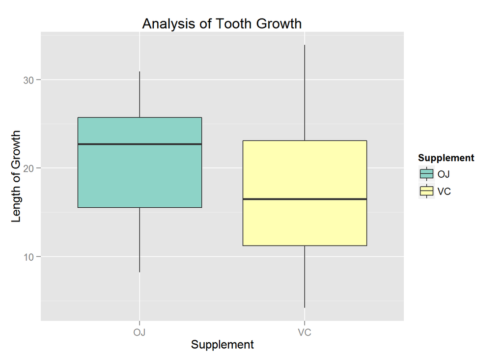

Based on the plot, we see that the ascorbic acid produced a wider range of lengths, but the median length was higher for those that received OJ as the supplement.

To take it a step further, let’s investigate each Supplement by does and observe the range and median of those

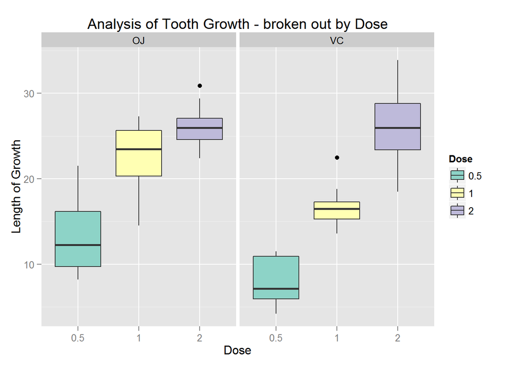

We can see clearly, that at Dose=2 the median length of growth is quite similar for both supplements.

#### Question 3. Response as follows;

In order to better understand which one was truly more effective, let’s use a t test. Using a 95% confidence interval let’s compare the supplements

```r
#Start by subsetting the data so we can gather intervals
dose2<-subset(ToothGrowth, dose==2)
dose1<-subset(ToothGrowth, dose==1)
dose.5<-subset(ToothGrowth, dose==.5)
```

Let’s examine the entire data set

```
##
##  Welch Two Sample t-test
##
## data:  len by supp
## t = 1.9153, df = 55.309, p-value = 0.06063
## alternative hypothesis: true difference in means is not equal to 0
## 95 percent confidence interval:
##  -0.1710156  7.5710156
## sample estimates:
## mean in group OJ mean in group VC
##         20.66333         16.96333
```

We can dig even deeper into the data.

Let’s test the half dose first

```
##
##  Welch Two Sample t-test
##
## data:  len by supp
## t = 3.1697, df = 14.969, p-value = 0.006359
## alternative hypothesis: true difference in means is not equal to 0
## 95 percent confidence interval:
##  1.719057 8.780943
## sample estimates:
## mean in group OJ mean in group VC
##            13.23             7.98
```

The results here inform us that the the interval is between 1.72 and 8.78 Since 0 is not included in the interval, we conclude that the greater mean length of teeth with supplement OJ is statistically significant

Now let’s test the 1 dose

```
##
##  Welch Two Sample t-test
##
## data:  len by supp
## t = 4.0328, df = 15.358, p-value = 0.001038
## alternative hypothesis: true difference in means is not equal to 0
## 95 percent confidence interval:
##  2.802148 9.057852
## sample estimates:
## mean in group OJ mean in group VC
##            22.70            16.77
```

The results in this case inform us that the interval is between 2.80 and 9.06 Since 0 is not included in this interval, we conclude tha the greater mean length of teeth with supplement OJ is statistically significant

Now let’s test the 2 dose

```
##
##  Welch Two Sample t-test
##
## data:  len by supp
## t = -0.046136, df = 14.04, p-value = 0.9639
## alternative hypothesis: true difference in means is not equal to 0
## 95 percent confidence interval:
##  -3.79807  3.63807
## sample estimates:
## mean in group OJ mean in group VC
##            26.06            26.14
```

The results in this case inform us that the interval is between -3.80 and 3.64 Since 0 is included in this interval, we can not reject the null hypothesis Therefore, we remain uncertain as to whether OJ or VC contributes to greater tooth length

Since we just explored the difference between the two supplements, let’s examine the contibution of the variable ‘dose’ to the length of teeth for each of those two supplements.

```r
#Subset the OJ supplements by dose
oj2<-subset(ToothGrowth, supp=="OJ" & dose==2)
oj1<-subset(ToothGrowth, supp=="OJ" & dose==1)
oj.5<-subset(ToothGrowth, supp=="OJ" & dose==.5)
```

Compare the oj1 to the oj.5 to see if the change in dose is attributable to greater length

```
##
##  Welch Two Sample t-test
##
## data:  oj.5$len and oj1$len
## t = -5.0486, df = 17.698, p-value = 8.785e-05
## alternative hypothesis: true difference in means is not equal to 0
## 95 percent confidence interval:
##  -13.415634  -5.524366
## sample estimates:
## mean of x mean of y
##     13.23     22.70
```

We observe an interval of -13.42 and -5.52, which does not include 0 We can then conclude that the greater mean length associate with the higher dose is statistically significant.

Compare the oj1 to the oj2 to see if the change in dose is attributable to greater length

```
##
##  Welch Two Sample t-test
##
## data:  oj1$len and oj2$len
## t = -2.2478, df = 15.842, p-value = 0.0392
## alternative hypothesis: true difference in means is not equal to 0
## 95 percent confidence interval:
##  -6.5314425 -0.1885575
## sample estimates:
## mean of x mean of y
##     22.70     26.06
```

We observe an interval of -6.53 and -.19, which does not include 0 We can then conclude that the greater mean length associate with the higher dose is statistically significant.

```r
#Subset the VC supplements by dose
vc2<-subset(ToothGrowth, supp=="VC" & dose==2)
vc1<-subset(ToothGrowth, supp=="VC" & dose==1)
vc.5<-subset(ToothGrowth, supp=="VC" & dose==.5)
```

Compare the vc1 to the vc.5 to see if the change in dose is attributable to greater length

```
##
##  Welch Two Sample t-test
##
## data:  vc.5$len and vc1$len
## t = -7.4634, df = 17.862, p-value = 6.811e-07
## alternative hypothesis: true difference in means is not equal to 0
## 95 percent confidence interval:
##  -11.265712  -6.314288
## sample estimates:
## mean of x mean of y
##      7.98     16.77
```

We observe an interval of -11.27 and -6.31, which does not include 0 We can then conclude that the greater mean length associate with the higher dose is statistically significant.

```
##
##  Welch Two Sample t-test
##
## data:  vc1$len and vc2$len
## t = -5.4698, df = 13.6, p-value = 9.156e-05
## alternative hypothesis: true difference in means is not equal to 0
## 95 percent confidence interval:
##  -13.054267  -5.685733
## sample estimates:
## mean of x mean of y
##     16.77     26.14
```

We observe an interval of -13.05 and -5.69, which does not include 0 We can then conclude that the greater mean length associate with the higher dose is statistically significant.

### Conclusions and Assumptions

Conclusions:

1. The pigs given doses of .5 or 1 experience greater growth with supplement “OJ”
2. Increseases in dossages lead to greater tooth length.
3. All pigs that received a dose of 2, regardless of supplement, registered simlar relative growth

Assumptions:

1. Variances are not equal, hence var.equal=F
2. The data is not paired